# Basal statistik

Max Gordon

October 12, 2016

# Vad är statistik?

- Ett nödvändigt ont?
- Något vi tvingas till?
- Ett verktyg?

# Varför kunna statistik?

Alternativ 1: “hålla hakarna”

Alternativ 2: “operera själv”

*En subjektiv föreläsning*

# Statistiknivåer

1. Deskriptiv statistik (medelvärde, median)
2. Effektstorlekar (fisher, t-test, regressioner)
3. Prediktion (machine learning)

# Vad innebär ett sample?

- Slumpmässigt urval

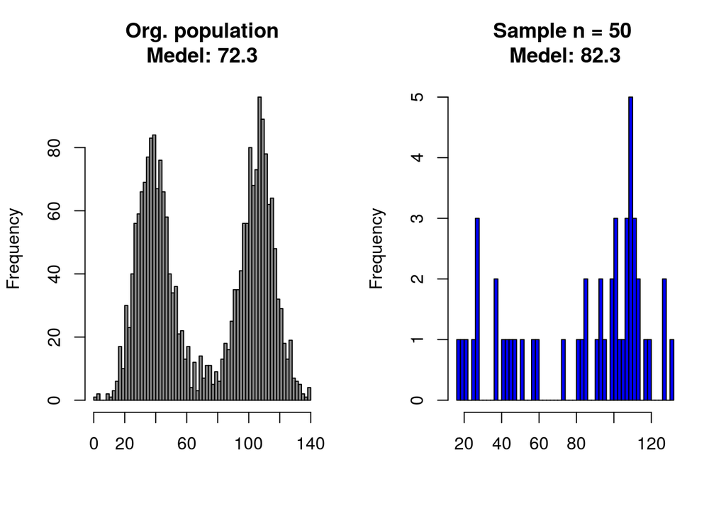

# Sample lite fler

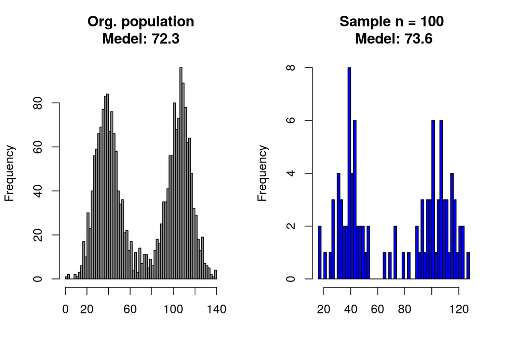

# Ännu lite fler

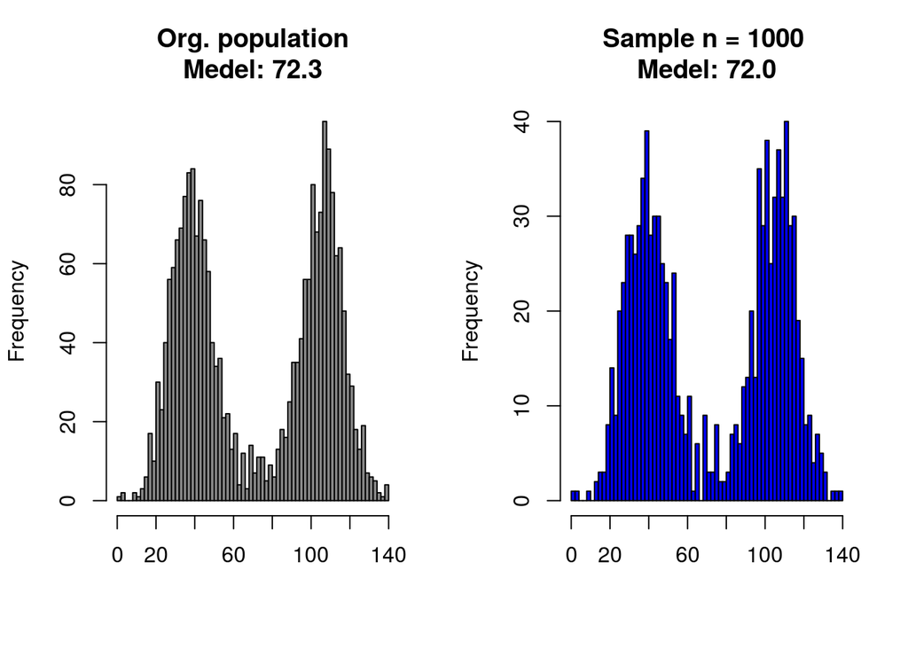

# Centrala gränsvärdessatsen

- En av de viktigaste verktygen
- Intuitivt inte så svår att förstå

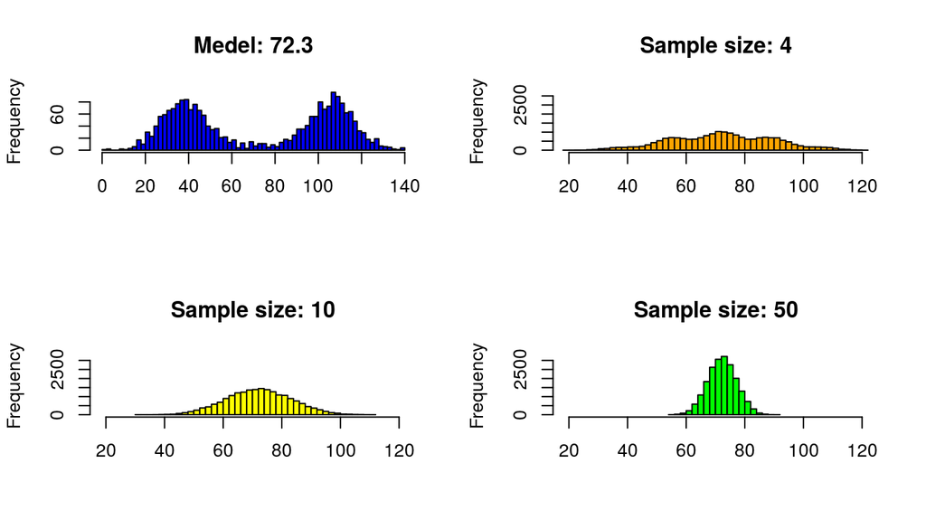

# So what!?

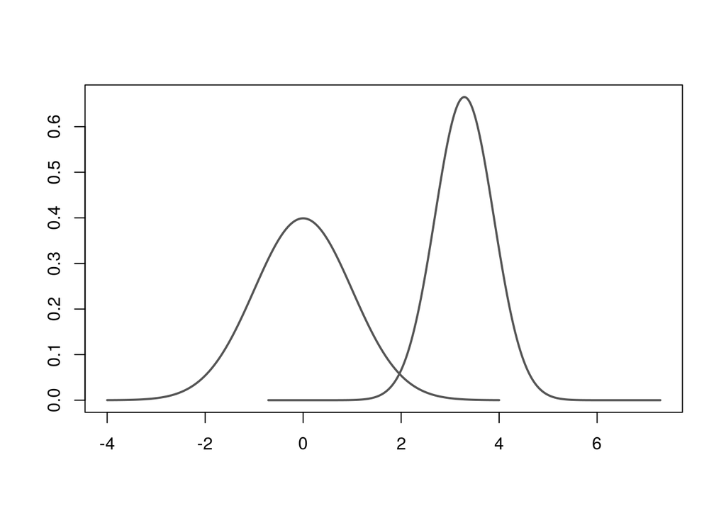

# So what!?

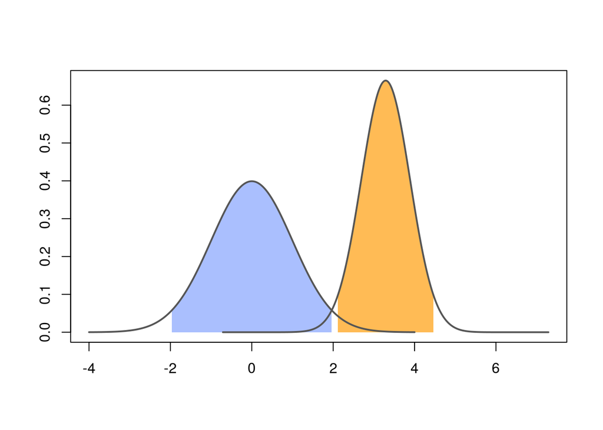

# P-värden

- Användbara?
- Problematiska?

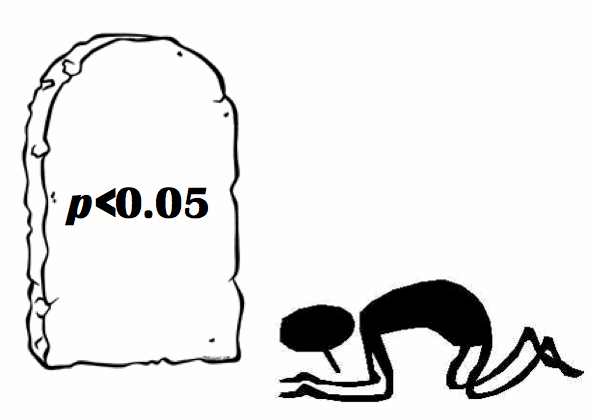

# En klassiker

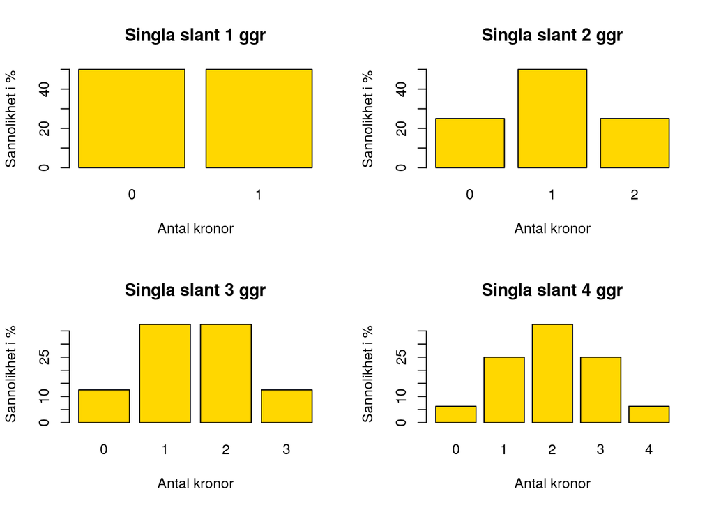

# Ett exempel

- 2 st kronor av 10 singlingar

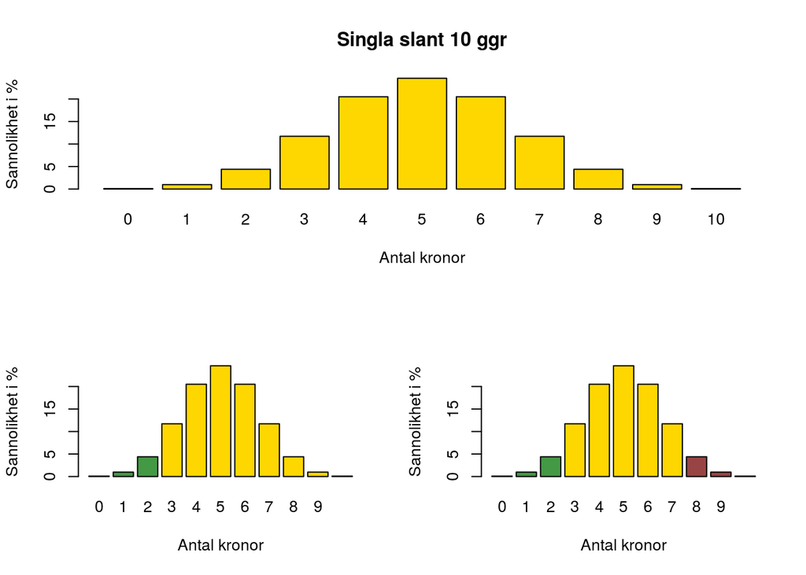

# Att vara parametrisk eller inte?

### Parametrisk metod = gör antaganden

### Icke-parametrisk = gör inga/få antaganden

# Att vara parametrisk eller inte?

### Parametrisk metod = gör antaganden

- Ger tolkningsbart storleksestimat
- Antagandena ibland svåra att testa
- Ex. regressioner, t-test

### Icke-parametrisk = gör inga/få antaganden

- Ger ett svårtolkat storleksestimat
- “Alltid sant” men “inte alltid relevant”"
- Ex. Fischers exakta test, Wilcoxon rank-sum test

# Regression

Löser ekvationen

$$y = a + b * x$$

t.ex.

$$Syst. BT = basnivå + \beta_{ålder} * ålder$$

# Regression forts I

- Enkelt koncept

$$Syst. BT = basnivå + \beta_{ålder} * ålder$$

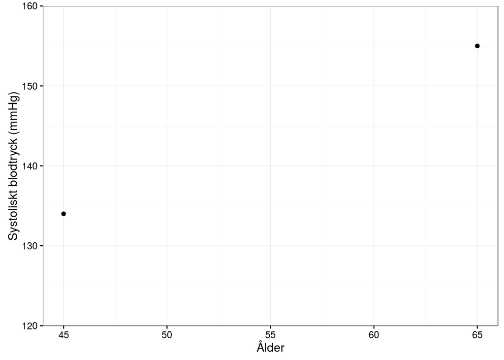

# Regression forts I

- Enkelt koncept

$$Syst. BT = basnivå + \beta_{ålder} * ålder$$

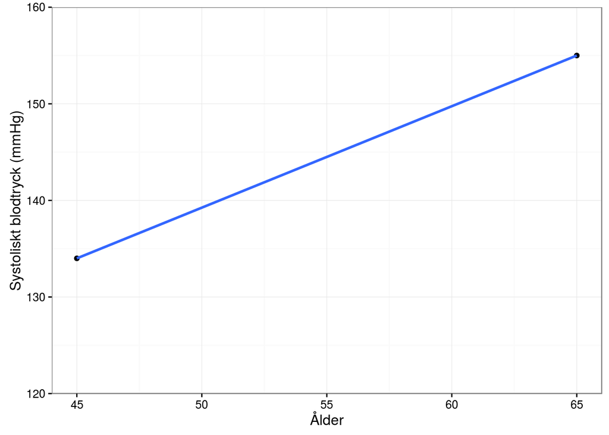

# Regression forts II

$$Syst. BT = basnivå + \beta_{ålder} * ålder$$

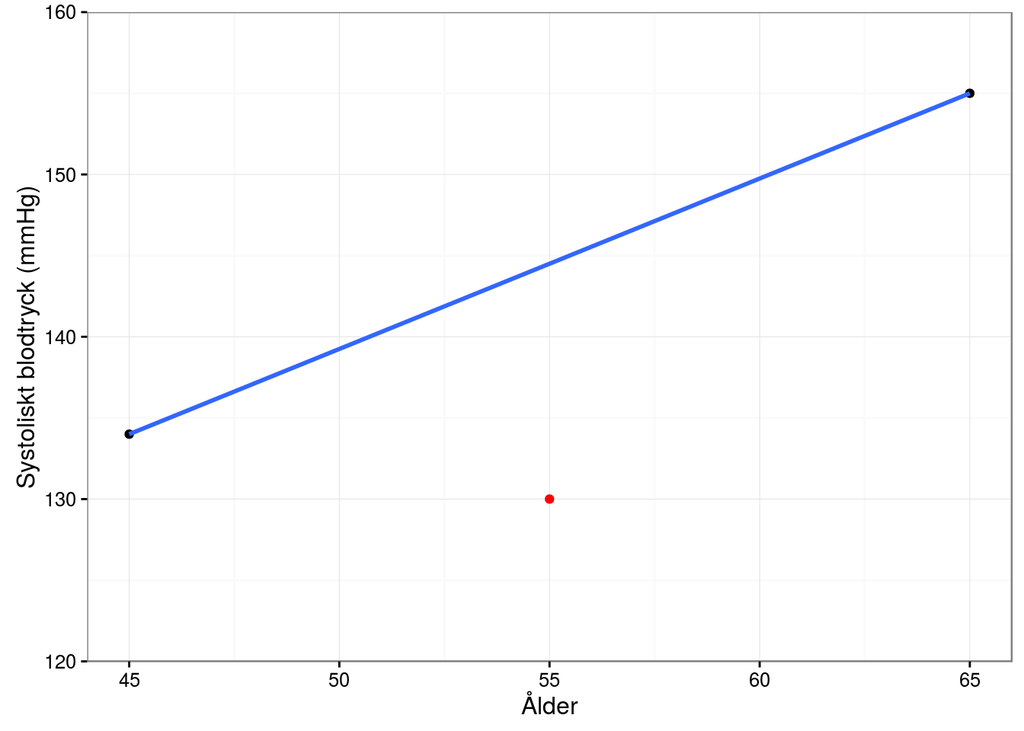

# Regression forts II

$$Syst. BT = basnivå + \beta_{ålder} * ålder$$

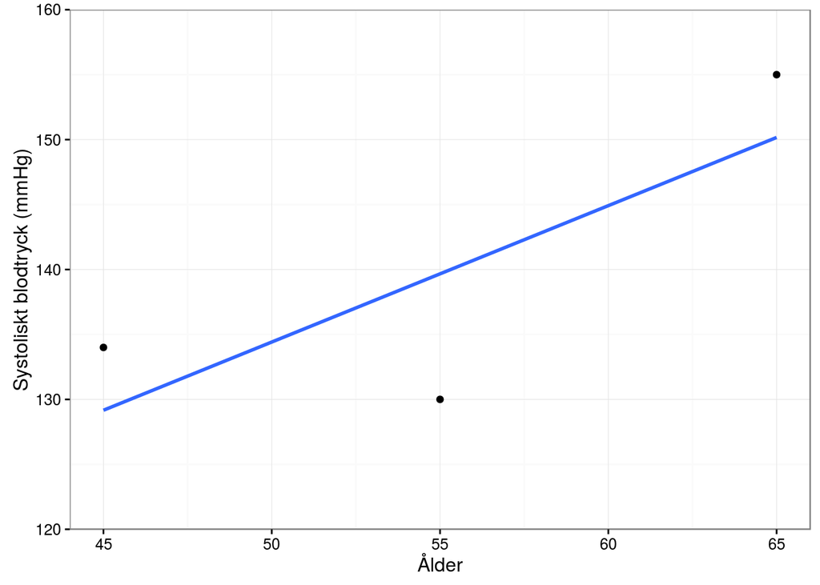

# Regression forts III

### Att byta y-axeln

- Binära variabler (ex. logistisk regression)
- Risk över tid (Cox regression)
- Antal händelser (Poisson regression)
- …

# Regression forts IV

### Öka komplexitent allteftersom

- Icke-linjära förhållanden
- Interaktioner
- Random effects

# Sammanfattning

- Vi kan förutspå hur sammanslagna värden kommer bete sig
- Vi kan aldrig säga att något inte är sant bara hur låg sannolikhet det observerade fallet har
- Parametriska tester är lättare att förstå
- Regressioner är det ni pysslade med på högstadiet som tagits till en användbar nivå

# Sen då?

- Data munging
- “Fast-track publishing” med R
- Icke-linjära regressioner
- Avancerad regressionsmodellering
- Överlevnadsanalyser
- Epidemiologi
- DAG
- Bootstrapping
- Random effects
- Machine learning
- Neurala nätverk

Max Gordon, Ortopeden, Danderyds Sjukhus